# Master's Degree in Particle Physics and Cosmos UC-UIMP

# M1991- Statistics and data analysis. Course 2019-2020

### Exercise 3. Statistical modelling of data

### Jazmin Morales Morales

#### Abstract

Given a table which contains the number of nights lost due to bad weather in an astronomical observatory, by months and years, the possible seasonal and long-term variation of the fraction of nights lost due to bad weather are analised. Such analysis is made through $chi^2$ statistics, in order to determine the goodness of fit for the models. When the fraction lost per year was taken into account, both the constant fit and the linear fit are consistent with data; in the other hand, for the fraction lost per month, the model that better describes the data involves a sinusoidal function.

### Introduction

The analysis in this exercise is made under the following assumptions:

- The different months and years are independent statistical samples.
- Gaussianity in data and statistical errors

In order to treat the information given, the fractionf of nights lost due to bad weather is calculated for each year and for each month, resulting in sequence tuples:

$$\{ x_i, y_i, \sigma_i \} $$

Where $x_i$ is the year or month, $y_i$ is the fraction lost and $\sigma_i$ is the statistical error.

Given a model $f(\theta_1, ...,\theta_p)$ for the data, the goodnes of the fit is described by $\chi^2$ statistics , which is defined as (1):

$$\chi^2 (\theta_1, ..., \theta_p)= \sum_i^N \left( \frac{y_i - f(\theta_1, ..., \theta_p)}{\sigma_i} \right)^2 $$

Three kinds of models are applied to observe the behaviour of the data: constant, linear and a curve.

- Linear fit $y(x; a, b)= a + bx$:

The analytical solution $\chi^2$ is given by:

$$ \chi ^2 (x) = \sum^N_i \left( \frac{y_i-a-bx_i}{\sigma_i} \right) ^2 $$

With parameters $a,b$ (its determination is necessary for the characterisation of the model).

- Constant fit $y(x;a) = a$:

It is similar to linear fit for the case $b=0$. Then $\chi^2$ is :

$$ \chi ^2 (x) = \sum^N_i \left( \frac{y_i-a}{\sigma_i} \right) ^2 $$

- Curve $f(x; f_c, f_e, t_0 ) = fc + fe\times \sin(2\pi(x-t_0)/12)$:

For the three parameters $f_c, f_e, t_0$, $\chi^2 $ is given by :

$$ \chi^2 (f_c, f_e, t_0) = \sum^N_i \left( \frac{y_i-f(x;f_c, f_e, t_0 )}{\sigma_i} \right) ^2 $$

The goodnes of fit $Q$ of a $\chi^2$ fit is determined by:

$$ Q(\chi^2, \nu) = 1-P(\chi^2, \nu)$$

Where $P(\chi^2, \nu) = \text{Probability that} \chi^2 < \chi^2_{min}$ if the model is correct

If $Q=1-P << $, the model is not consistent with the data.

If $P << $, the model may correspond with the data.

$\nu$ is the number of degrees of freedom (the difference of independent data $N$ and the number of fitted parameters $p$):

$$\nu = N-p $$

Once the models are given, it is possible to know if the use of a model is better than the other; $F$ statistics allows to do it:

$$ F = \left( \frac{\chi_1^2-\chi_2^2}{\nu_1-\nu_2} \right) / \left( \frac{\chi_2^2}{\nu_2} \right) $$

When a model 2 improves on model 1, the probability $P$ is low.

### Part 1)

### 3. 1 Fraction lost vs year

First of all, the libraries necessary for the data analysis are:

```r
library(Hmisc)
library(lubridate)
library(data.table)
library(formattable)
```

Importing data and excluding cells whit any data, giving as a result 'data1':

```r
data <- read.csv('DataExercise3.csv')
data1 <- data[1:22,1: 13]
#data1
```

```
     a)  In order to convert nights to fraction of nights for each year, is necessary to know the number of days for each month in data1:
```

```r
### giving a sequence of months from january 1984, to december 2005.

dates = seq(as.Date('1984/1/1'), as.Date('2005/12/31'),  by = 'month')

### Number of days for each month in 'dates' sequence

days = matrix(days_in_month(dates), nrow=22, ncol=12, byrow = TRUE)


### the fraction of nights for each month is: fraction_months =  observation nights / total of days in each month

fraction_year = data1[1:22,2:13]/days

#dates
#days
#fraction_year
```

```
       b) Mean fraction + error in the mean
```

The mean and the error of the measurements in data1 have to be computed excluding dates when there were any observation (cells with 'NA'):

*means* for each year can be computed with 'rowMeans' function.

For *error* :

$$ \text{error} = \text{standard deviation for days with observation} / \sqrt{\text{N}} $$

Whit $N$ the number of data.

```r
### mean for observations for each year, excluding 'NA' cells

mean_years = rowMeans(fraction_year, na.rm = TRUE)

### standard deviation for observations foe each year

STD = apply(fraction_year, 1, sd, na.rm=TRUE)


### error for observations for each year
error_years = STD / sqrt(rowSums(!is.na(fraction_year)))
```

```
        c) Final table: YEAR | FRACLOST |  ERROR

        d) Plot FRACLOST vs YEAR
```

| Year | Fraclost | Error |
| --- | --- | --- |
| 1984 | 0,1252016 | 0,03641051 |
| 1985 | 0,2311476 | 0,04975791 |
| 1986 | 0,1541475 | 0,04205410 |
| 1987 | 0,2184076 | 0,04608115 |
| 1988 | 0,1680061 | 0,03092405 |
| 1989 | 0,2804820 | 0,05906778 |
| 1990 | 0,2635241 | 0,04954609 |
| 1991 | 0,2152682 | 0,05113503 |
| 1992 | 0,2327030 | 0,04947453 |
| 1993 | 0,2309716 | 0,04577177 |
| 1994 | 0,1830165 | 0,03952987 |
| 1995 | 0,2187244 | 0,05133462 |
| 1996 | 0,3182734 | 0,05780758 |
| 1997 | 0,2537922 | 0,05092741 |
| 1998 | 0,1364631 | 0,03408173 |
| 1999 | 0,2238340 | 0,07959213 |
| 2000 | 0,1974212 | 0,05921931 |
| 2001 | 0,2384647 | 0,07026017 |
| 2002 | 0,3039939 | 0,05291902 |
| 2003 | 0,2179647 | 0,04378841 |
| 2004 | 0,3651619 | 0,05286236 |
| 2005 | 0,3157930 | 0,10757559 |

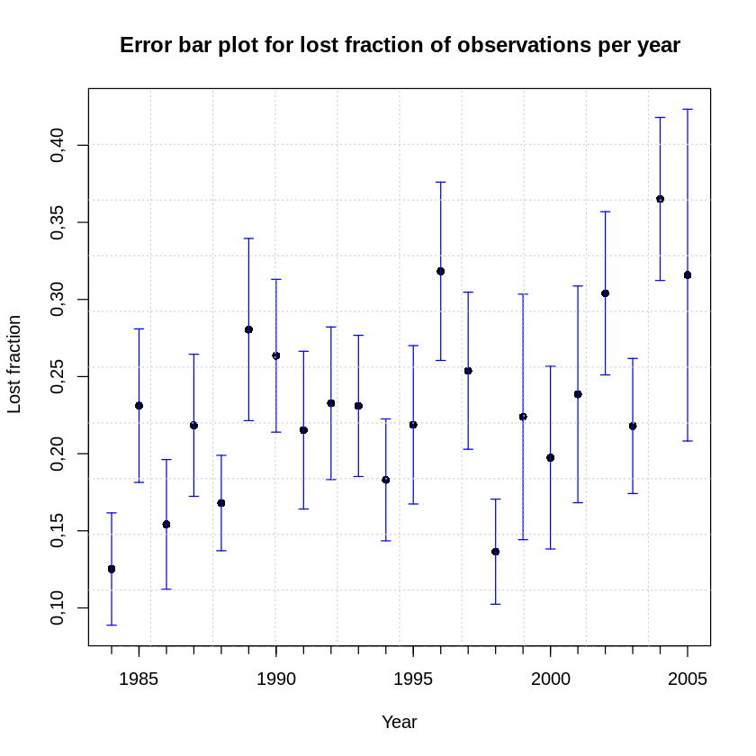

```r
#### years shown in data1
years <- data1[1:22,1]


##### For table

table1 <- data.frame(Year = years, Fraclost = mean_years, Error = error_years)

table_fraclost_year <- formattable(table1)
table_fraclost_year

#### For plot

errplot1 <- errbar(years, mean_years,
                   yplus= mean_years+error_years,
                   yminus = mean_years-error_years,
                  main = 'Fraction of lost nights vs',
                  xlab = 'Year', ylab = ' Lost fraction',
                  errbar.col = 'blue', lty = 1)

thicks <- seq(1984, 2004, 1)
axis(1, at = thicks, labels = FALSE, lty = 5)
grid(nx = 10, ny = 10, col = "lightgray", lty = "dotted")
title(main='Error bar plot for lost fraction of observations per year')
```

### 3.1. a) Fit to a constant

**a1)** Use 'lm' and 'analytical expresion' to fit a constant

- The formula to use in **lm** for a constant, $y = cte.$, is:

$$y \sim 1$$

Errors can be taken into account in the fit: $$\text{weight} = 1/\sigma_i $$

with $\sigma_i$ the error in data1.

- The **analytical expression** for $\chi^2$ when fitting to a constant, $y = a$ is :

$$ \chi ^2 (x) = \sum^N_i \left( \frac{y_i-a}{\sigma_i} \right) ^2 $$

The minimum $a_0$ is:

$$ a_0 = \sum^N_i \frac{y_i}{\sigma_i^2}/\sum \frac{1}{\sigma_i^2} $$

```r
#### fit for 'lm'


fit_lm_years <- lm(mean_years ~ 1, weights = 1 / (error_years^2))


c('a0 value for lm fit', coef(fit_lm_years))


###############  fit with analytical expression

### chi^2 when fitting to a constant

fit_ct <- function(yi, sigmai){
        chi2 <- sum(yi/(sigmai)^2)/sum(1/sigmai^2)
        return(chi2)
}


c('a0 value for analytical expression: ', fit_ct(yi = mean_years, sigmai = error_years))

#### chi^2 for a0 computed with 'lm'
```

**1**

'a0 value for lm fit'

**(Intercept)**

'0,211552503264416'

1. 'a0 value for analytical expression: '

2. '0,211552503264416'

**a2)** Calculate $\chi^2 $

In the case of a line $f(x; a,b) = a + bx$

$\chi^2$ is given as:

$$\chi^2 = \sum^N_i \left( \frac{y_i - a - bx_i}{\sigma_i} \right)^2 $$

For a constant $b = 0$, and $a=a_0$

```r
#### function to calculate chi2 for a line

chi2_linear <- function(p,yi, xi, sigmai){
    a <- p[1]
    b <- p[2]
    chi2 <- sum(((yi-a-b*xi)/ sigmai)^2)
    return(chi2)
}

### if the model is a constant, b=0

a <- fit_ct(yi = mean_years, sigmai = error_years)  ## minimum value for a model with a constant
b <- 0
yi <- mean_years
xi <- years
sigmai <- error_years    ## error

chi_c <- chi2_linear(p=c(a,b), yi, xi, sigmai)
c('chi^2 value for constant fit with optim', chi_c)

c('chi^2 value for constant fit with lm', chi2_linear(p=c(a=coef(fit_lm_years),b=0), yi, xi, sigmai))
```

1. 'chi^2 value for constant fit with optim'

2. '34,6522105477339'

1. 'chi^2 value for constant fit with lm'

2. '34,6522105477339'

**a3)** Calculate 90% confidence interval.

For 1-parameter, the value of $\Delta \chi^2 $ with enclosed probability of 90% is: $ \Delta \chi^2 = 2.71$ (Blake, C.)

Where $$\Delta \chi^2 =\sum_i^N \frac{N(a-\bar{y})^2}{\sigma_i^2}$$

$$\Rightarrow a = \bar{y} \pm \sqrt{\Delta \chi^2/ N}\sigma $$

With $\bar{y} = a_0$

```r
####  a_conf is the function for the confidence interval

a_conf <- function(a0, N, sigma){
    a_left = sum(a0 - (sqrt(2.71 / N) * sigma))
    a_right = sum(a0 + (sqrt(2.71 / N) * sigma))
    return(c(a_left, a_right))
}

print('90% confidence interval:')
ci_ct <- a_conf(a0=a, N=rowSums(!is.na(fraction_year)), sigma=error_years)
ci_ct
```

```
[1] "90% confidence interval:"
```

1. 1,63799673536318

2. 2,7937663226616

### 3.1. b) Fitting quality

**b1)** Probability that $\chi^2 < \chi^2_{min}$ if the model is correct

Probability that $\chi^2 < \chi^2_{min} = P(\chi^2, \nu) $

**b2)** Q (goodness of fit) = Probability that $\chi^2 > \chi^2_{min}$ if the model is correct

The degrees of freedom are $\nu = N-p$, with $p$ the number of fitted parameters.

In this case, N=22 (number of years), and $p=1$, only one parameter for the constant fit.

```r
### b1) P(chi, nu) can be computed from 'pchisq'




c('P(chi2, nu) -->',  pchisq(chi_c, df=21 , lower.tail=TRUE))


### b2)


c('Q(chi2, nu) -->', pchisq(chi_c, df = 21,lower.tail=FALSE))
q_ct <- pchisq(chi_c, df = 21,lower.tail=FALSE)

#print(Q()
```

1. 'P(chi2, nu) -->'

2. '0,969182844298684'

1. 'Q(chi2, nu) -->'

2. '0,0308171557013157'

### 4.1.c) Fit to a straight line

*flost = a + b * years*

**c1)** Best fit (by `lm`) and plot

$y \sim x$ for $ y = ax + b$

**c2)** Best fit con `optim`

As it was mentioned in part *a2)* , $\chi^2$ is given by: $$\chi^2 = \sum^N_i \left( \frac{y_i - a - bx_i}{\sigma_i} \right)^2 $$

The function 'chi2_linear' gives the value of chi2 for a linear fit

```
chi2_linear <- function(p,yi, xi, sigmai){
    a <- p[1]
    b <- p[2]
    chi2 <- sum(((yi-a-b*xi)/ sigmai)^2)
    return(chi2)
}
```

In this case, $b \neq 0$.

```r
############  c1) y~x for a line
fit_lm_line <- lm(mean_years ~ years, weights = 1 / (error_years^2))

print('Linear fit for lm: ')
coef(fit_lm_line)




#### from 'chis_linear', some initial values for a, b are given

chi2_linear <- function(p,yi, xi, sigmai){
    a <- p[1]
    b <- p[2]
    chi2 <- sum(((yi-a-b*xi)/ sigmai)^2)
    return(chi2)
}


a <- -8.946
b <- 0.0045

####
solution <- optim(c(a,b), chi2_linear, yi = mean_years, xi = years, sigmai=error_years)


#### values for parameters a,b after optim

new_a = solution$par[1]
new_b = solution$par[2]


### chi^2 for the parameters a,b from 'optim'

new_chi2 <- chi2_linear(p=c(new_a, new_b), yi, xi, sigmai)

print("Chi^2 for linear fit whit 'optim':")
new_chi2


### chi^2 for parameters a,b after 'lm'
print("Chi^2 for linear fit whit 'optim':")
chi2_linear(p=c(new_a, new_b), yi = mean_years, xi = years, sigmai=error_years)
```

```
[1] "Linear fit for lm: "
```

**(Intercept)**

-8,94636539431913

**years**

0,00459491475266211

```
[1] "Chi^2 for linear fit whit 'optim':"
```

26,8425230914357

```
[1] "Chi^2 for linear fit whit 'optim':"
```

26,8425230914357

```r
### plotting results

png("linefit.png", width = 800, height = 800)
errplot <- errbar(years, mean_years, yplus=mean_years+error_years, yminus=mean_years-error_years,
                 xlab = 'Years', ylab ='Fraction lost')

#chis_l <- chis_linear(x = years, y = mean_data, p=c(new_a, new_b), sigma = error_mean)
abline(a = new_a, b = new_b, years, col='green', lw = 2)

abline(fit_lm_line, col='red', lty = 3, lw=2)
abline(h=0.2115, col='blue', lty = 6)

thicks <- seq(1984, 2004, 1)
axis(1, at = thicks, labels = FALSE, lty = 5)
grid(nx = 10, ny = 10, col = "lightgray", lty = "dotted")
legend("topleft",c("data","fit lm", 'fit optim', 'constant fit'),
       lty=c(1,2,2,6),col=c("black","green",'red', 'blue'),bty="n")
title(main=expression('Linear fit for fraction lost'))
dev.off()
```

**png:** 2

**c3)** Confidence intervals 90% and 99%

For linear fit, the confidence interval is given by $b_\delta$:

$$ b_\delta = b_0 \pm \sigma_0\sqrt{\delta} $$

Where:

$$\sigma_0 = \sqrt{1/(S_{xx}-S_x^2/S)} $$

$ S =\sum^N_i \frac{1}{\sigma^2_i} $,

$ S_x =\sum^N_i \frac{x_i}{\sigma^2_i} $,

$ S_{xx} =\sum^N_i \frac{x_i^2}{\sigma^2_i} $

```r
##### S

s <- sum(1/error_years^2)

#### Sx

sx <- sum(years/(error_years^2))

### Sxx

sxx <- sum(years^2/error_years^2)


### function for confidence interval:

b_conf <- function(b0, sigma0, delta){
    b_left = b0 - sigma0*sqrt(delta)
    b_right = b0 + sigma0*sqrt(delta)
    return(c(b_left, b_right))
}


sigma0 <- sqrt(1/(sxx-sx^2/s))

### b0 is the minimum of chi^2, i.e par[2]
b0 <- solution$par[2]


### for 90% confidence interval
delta1 <- 2.71

### for 99% confidence interval
delta2 <- 6.63


### 90%
print('90% confidence interval:')
b_conf(b0, sigma0, delta=delta1)


### 99%
print('99% confidence interval')
b_conf(b0, sigma0, delta=delta2)
```

```
[1] "90% confidence interval:"
```

1. 0,00188955943507778

2. 0,00730302301690685

```
[1] "99% confidence interval"
```

1. 0,000362617917977107

2. 0,00882996453400753

**c4)** Ftest

The F statistics is defined as:

$ F = \left( \frac{\chi_1^2-\chi_2^2}{\nu_1-\nu_2} \right) / \left( \frac{\chi_2^2}{\nu_2} \right) $

Where $\chi_1^2$, $\nu_1$ stands for the constant fit; $\chi^2_2$, $\nu_2$ is the $\nu_2$ stands for the linear fit.

The improvement for models 1,2 is $\text{improve} = 1 - \text{pf}$

```r
### F statistics

Fs <- function(nu1, nu2, chi1, chi2){
    num <- (chi1 - chi2)/(nu1 - nu2)
    den <- chi2/nu2
      f <- num/den
    return(f)
}


### degrees of freedom for constant fit

nu1 <- 22-1

### degrees of freedom for a linear fit
nu2 <- 22-2

## chi^2 for constant fit
chi1 <- chi_c

## chi^2 for linear fit
chi2 <- new_chi2


## F statistics

Fstatistics <- Fs(nu1, nu2, chi1, chi2)

print('F statistics for constant and lineal fits')
Fstatistics



#######
#######  pF

pval <- pf(Fstatistics, df1=nu1, df2=nu2)

print('pf for Fstatistics')
pval



###
#### Improve

imp <- 1- pval

print('Improve')
imp
```

```
[1] "F statistics for constant and lineal fits"
```

5,8188922328169

```
[1] "pf for Fstatistics"
```

0,999890591268937

```
[1] "Improve"
```

0,000109408731063021

## Part 2

### 3.2) Fraction Lost vs. Month (7)

This time, the table constains the month, fraction lost and the error.

```r
### sequence for months
months <- seq(1,12,1)

### mean of nigths lost per month
mean_months <- colMeans(fraction_year, na.rm = TRUE)

### SD for months
col_STD <- apply(fraction_year,2, sd, na.rm=TRUE)


### error in observations per month
error_months = col_STD / sqrt(colSums(!is.na(fraction_year)))

### table

table2 <- data.frame(Fraclost = mean_months, Error = error_months)


formattable(table2)
```

|  | Fraclost | Error |
| --- | --- | --- |
| Ene | 0,36903226 | 0,046285072 |
| Feb | 0,32307061 | 0,050001081 |
| Mar | 0,30952381 | 0,027806944 |
| Abr | 0,25492063 | 0,034031280 |
| May | 0,18509985 | 0,025319402 |
| Jun | 0,05614035 | 0,008280586 |
| Jul | 0,04584041 | 0,012472969 |
| Ago | 0,06513057 | 0,009350916 |
| Sep | 0,20825397 | 0,026277537 |
| Oct | 0,30046083 | 0,032964076 |
| Nov | 0,34412698 | 0,038412206 |
| Dic | 0,31367127 | 0,036888754 |

**a)** Fit to a constant (`lm`), Give chi2

In section *3.1a)*, the function for a constant fit was given by function `fit_ct`:

```
fit_ct <- function(yi, sigmai){
        chi2 <- sum(yi/(sigmai)^2)/sum(1/sigmai^2)
        return(chi2)
}
```

In this case $yi = \text{mean_months}$, $\text{sigmai} = \text{error_months}$

And $\chi^2$ was computed from function `chi2_linear`:

```
chi2_linear <- function(p,yi, xi, sigmai){
    a <- p[1]
    b <- p[2]
    chi2 <- sum(((yi-a-b*xi)/ sigmai)^2)
    return(chi2)
}
```

```r
### fit with 'lm', y ~ 1

fitlm_months <- lm(mean_months ~ 1, weights = 1 / (error_months^2))


#### fit with analytical expression, minimum 'a' value for months: a0m

#### function to chi^2 when fitting to a constant
### if the model is a constant, b=0

a0m <- fit_ct(mean_months, error_months)
a <- a0m
b <- 0
yi <- mean_months
xi <- months
sigmai <- error_months    ## error


c('chi^2 value for constant fit with optim', chi2_linear(p=c(a,b), yi, xi, sigmai))

c('chi^2 value for constant fit with lm', chi2_linear(p=c(a,b=0), yi, xi, sigmai))

chi2_cm <- chi2_linear(p=c(a,b), yi, xi, sigmai)



#### confidence interval
print('90% confidence interval:')
ci_cm <- a_conf(a0=a, N=colSums(!is.na(fraction_year)), sigma=error_months)
ci_cm
```

1. 'chi^2 value for constant fit with optim'

2. '331,172352632465'

1. 'chi^2 value for constant fit with lm'

2. '331,172352632465'

```
[1] "90% confidence interval:"
```

1. 1,08282411743841

2. 1,33450118693874

**b)** Fit to a function $flost = fc + fe\times \sin(2\pi(t-t_0)/12)$

```r
# initial function to be fitted
flost <- function(params, x) {
       fc <- params[1]
       fe <- params[2]
       t0 <- params[3]
        f <- fc + fe*sin(2*pi*(x-t0)/12)
    return(f)
}



### function to minimize
fun.to.minimize.3pars <- function(params,x,y,var){
        fc <- params[1]
        fe <- params[2]
        t0 <- params[3]
        flost <- fc + fe*sin(2*pi*(x-t0)/12)
        output <- sum((y-flost)^2/var^2)
        return(output)
    }


## some initial values
fc <- 0.
fe <- 2.
t0 <- 0.

solution2 <- optim(c(fc, fe, t0), fun.to.minimize.3pars, x = months, y = mean_months,
                   var = error_months, hessian=TRUE)


## values
new.fc <- solution2$par[1]
new.fe <- solution2$par[2]
new.t0 <- solution2$par[3]


### chi2

print("Value of chi^2 fitting whit 'flost'")
newchi2_m <- fun.to.minimize.3pars(params=c(new.fc,new.fe,new.t0),y=mean_months, x = months, var=error_months)
newchi2_m
```

```
[1] "Value of chi^2 fitting whit 'flost'"
```

24,3698273745127

```r
### plot for fit with 'flost'

png("months_fit.png", width = 800, height = 800)

ticksmonths <- seq(1,12, 2)
errbar(months, mean_months,
       yplus=mean_months+error_months,
       yminus=mean_months-error_months, xaxt='n', col = 'blue',
       xlab = 'Months', ylab = 'Lost fraction')

abline(fitlm_months, col='purple', lty = 3, lw = 2)

curve(flost(c(new.fc,new.fe, new.t0),x),from=0,to=12 ,col='red',add=T)
axis(side = 1, at = 1:12, labels = F)
axis(side=1, at = ticksmonths, labels = c('Jan', 'March', 'May', 'Jul', 'Sep', 'Nov'))
grid(nx = 10, ny = 10, col = "lightgray", lty = "dotted")
legend("top", c('data error bar',"constant fit", '"flost" fit'),
       lty=c(1,2,1), col=c('black',"purple","red"),bty="n")
title( main = 'Fitting to "flost" ')

dev.off()
```

**png:** 2

**c1)** Confidence interval: Hessian matrices

```r
### 90% confidence interval

err_90 <- sqrt(diag(solve(solution2$hessian/2)))*1.64

print('90% confidence interval:')
c(new.fc - err_90[1], new.fc + err_90[1])


### 95% confidence interval
err_95 <- sqrt(diag(solve(solution2$hessian/2)))*1.96

print('95% confidence interval:')
c(new.fc - err_95[1], new.fc + err_95[1])


### 99% confidence interval
err_99 <- sqrt(diag(solve(solution2$hessian/2)))*2.58

print('99% confidence interval:')
c(new.fc - err_99[1], new.fc + err_99[1])
```

```
[1] "90% confidence interval:"
```

1. 0,211848039661124

2. 0,24038900513187

```
[1] "95% confidence interval:"
```

1. 0,209063555224954

2. 0,243173489568041

```
[1] "99% confidence interval:"
```

1. 0,203668616629874

2. 0,248568428163121

```r
#### P, Q

###  P(chi, nu) can be computed from 'pchisq'


### for constant fit

c('Ct fit: P(chi2, nu) -->',  pchisq(chi2_cm, df=11 , lower.tail=TRUE))


### b2)


c('Ct fit: Q(chi2, nu) -->', pchisq(chi2_cm, df = 11,lower.tail=FALSE))
q_cm <- pchisq(chi_c, df = 21,lower.tail=FALSE)

#print(Q()




##### for flost fit





c('flost fit: P(chi2, nu) -->',  pchisq(newchi2_m, df=11 , lower.tail=TRUE))


### b2)


c('flost fit: Q(chi2, nu) -->', pchisq(newchi2_m, df = 21,lower.tail=FALSE))
q_fm <- pchisq(newchi2_m, df = 21,lower.tail=FALSE)

#print(Q()
```

1. 'Ct fit: P(chi2, nu) -->'

2. '1'

1. 'Ct fit: Q(chi2, nu) -->'

2. '2,31995931332408e-64'

1. 'flost fit: P(chi2, nu) -->'

2. '0,988738991617907'

1. 'flost fit: Q(chi2, nu) -->'

2. '0,275486515012417'

```r
### tables

### years

ct_fit <- c(round(a,digits=6), 'NA', round(chi_c,digits=6),'     4,0762-- 5,2320 ',round(q_ct,digits=6))
lin_fit <- c(round(new_a, digits=6),round(new_b, digits=6), round(new_chi2,digits=6),
             '    0,0018--0,0073', round(imp, digits=6))


summ_fracyears <- matrix(c(ct_fit,lin_fit), ncol=5, nrow=2, byrow=TRUE)

rownames(summ_fracyears) <- c('Constant Fit', 'Linear Fit')
colnames(summ_fracyears) <- c('Par 1', 'Par 2', 'Chi^2', '90% conf. interval', 'Q')

#summ_fracyears


##### months

ct_fitm <- c(round(a0m,digits=6), 'NA', 'NA', round(chi2_cm,digits=6),
             '4,0762-- 5,2320 ', round(q_cm,digits=6))

f_fitm <- c(round(new.fc, digits=6), round(new.fe, digits=6), round(new.t0, digits=6),
            round(newchi2_m, digits=6), '1,0828--1,3345', round(q_fm,digits=6))


summ_fracm <- matrix(c(ct_fitm,f_fitm), ncol=6, nrow=2, byrow=TRUE)

rownames(summ_fracm) <- c('Constant Fit', 'Linear Fit')
colnames(summ_fracm) <- c('Par 1', 'Par 2', 'Par3','Chi^2', '90% conf. interval', 'Q')

#summ_fracm
```

### Results

**1.-** The `fractions of nights lost per year` is shown in Plot: 'Linear fit for fraction lost', as well as the fit to models constant and linear.

```r
print('Table 1. Summary for lost fraction for years')
summ_fracyears
print('F test for constant fit and linear fit:')
c('F=',imp)
```

```
[1] "Table 1. Summary for lost fraction for years"
```

[output not shown]

```
[1] "F test for constant fit and linear fit:"
```

2. '0,000109408731063021'

[figure not shown]

In the plot it can be seen that the two models differ, however the improvement of one model to other is very low, then it is possible to use describe the data with both models.

These results show that:

**2.-** Considering now the seasonal variation, the `fraction of nights lost per month`, the results for a constant fit $f(x,a)=a$, and for a sinusoidal function $flost = fc + fe\times \sin(2\pi(x-t_0)/12)$ are shown in plot 'Fitting to flost' and Table2.

```r
print('Table 2. Summary for lost fraction for months')
summ_fracm
#print('F test for constant fit and linear fit:')
#c('F=',imp)
```

[output not shown]

[output not shown]

[figure not shown]

In plot 'Fitting to flost', it can seen that the model which better describes the data is the one for *flost* : $fc + fe\times \sin(2\pi(x-t_0)/12)$

Given the results, it is possible to say that:

The model in this case is $f(x; f_c, f_e, t_0 ) = fc + fe\times \sin(2\pi(x-t_0)/12)$, with parameters $t_c=0.2261$, $t_e=0.1822$, $t_0 = -2.1277$

Other confidence intervals are:

`` -> "90% confidence interval:"

```
0,2118-- 0,2403
```

-> "95% confidence interval:"

```
0,2090-- 0,2431
```

-> "99% confidence interval:"

```
0,2036-- 0,2485
```

``

### Conclusions

After the analysis of data with different models it can be concluded that the variation of lost nights over the years 1984-2005 behaves linearly, although it is also possible to describe the behaviour as constant. In the case of seasonal variation, the fraction of lost nights for months can be seen like sinusoidal variations.

Knowing the goodness of a fit is very important since a model with a wrong description of the behaviour of a set of data is used can led to a misinterpretation of such data. $\chi^2$ is a method which allows to make a detailed analysis of data.

### References

- “Modern statistical methods for Astronomy” Feigelson& Babu, 2012, CUP
- “Data analysis” S. Brandt, 1999, Springer
- "Numerical Recipes" Press et al., 1994, CUP
- Blake, C. (n.d.). Hypothesis testing and model fitting. Retrieved from: http://astronomy.swin.edu.au/~cblake/StatsLecture3.pdf
- http://stats.stackexchange.com/questions/27033/in-r-given-an-output-from-optim-with-a-hessian-matrix-how-to-calculate-paramet)